# Petsc Pid Example

[figure not shown]

Jupyter Notebook source file

# PETSc Time-stepping Solver -- PID Control and Steam Example

This example provides an overview of the PETSc time-stepping solver utilities in IDAES, which can be used to solve systems of differential algebraic equations (DAEs). PETSc is a solver suite developed primarily by Argonne National Lab (https://petsc.org/release/). IDAES provides a wrapper for PETSc (https://github.com/IDAES/idaes-ext/tree/main/petsc) that uses the AMPL solver interface (https://ampl.com/resources/learn-more/hooking-your-solver-to-ampl/) and utility functions that allow Pyomo and Pyomo.DAE (https://pyomo.readthedocs.io/en/stable/modeling_extensions/dae.html) problems to be solved using PETSc.

This demonstration uses the IDAES PID controller model and a flowsheet arranged like so:

```
->--|><|------[]------|><|-->-
   valve_1   tank   valve_2
```

where the tank pressure is controlled by the opening of valve_1.

## Prerequisites

The PETSc solver is an extra download for IDAES. The solver is available for Linux, but can be run in the Windows environment via the WSL (Windows Subsystem for Linux). The WSL method of running the solver works smoothly in the normal Windows workflow. PETSc installation details for Linux and Windows are available along with the documentation (https://idaes-pse.readthedocs.io/en/latest/technical_specs/core/solvers.html).

You may want to review the "PETSc Time-stepping Solver -- Chemical Akzo Nobel Example" notebook first.

## Imports

```python
import numpy as np
import matplotlib.pyplot as plt

import pyomo.environ as pyo
import idaes.core.solvers.petsc as petsc # petsc utilities module
import pid
from idaes.core.util.math import smooth_max, smooth_min
```

## Model Set Up

```python
# to see the model code uncomment the line below
#??pid
```

```python
m = pid.create_model(
    time_set=[0, 12],
    nfe=1,
    calc_integ=True,
)
```

```
2022-03-08 01:23:04 [INFO] idaes.init.fs.valve_1: Initialization Complete: optimal - Optimal Solution Found
2022-03-08 01:23:04 [INFO] idaes.init.fs.tank.control_volume: Initialization Complete
2022-03-08 01:23:04 [INFO] idaes.init.fs.tank: Initialization Complete: optimal - Optimal Solution Found
2022-03-08 01:23:04 [INFO] idaes.init.fs.valve_2: Initialization Complete: optimal - Optimal Solution Found
```

## Solve

```python
res = petsc.petsc_dae_by_time_element(
    m,
    time=m.fs.time,
    ts_options={
        "--ts_type":"beuler",
        "--ts_dt":0.1,
        "--ts_monitor":"", # set initial step to 0.1
        "--ts_save_trajectory":1,
        "--ts_trajectory_type":"visualization",
    },
    vars_stub="pid_tj",
    trajectory_save_prefix="pid_tj",
)
```

[output not shown]

[output cut: 81 more lines]

```
2022-03-08 01:23:06 [INFO] idaes.solve.petsc-dae: 71 TS dt 0.169045 time 2.92877
2022-03-08 01:23:06 [INFO] idaes.solve.petsc-dae: 72 TS dt 0.184083 time 3.09782
2022-03-08 01:23:06 [INFO] idaes.solve.petsc-dae: 73 TS dt 0.203409 time 3.2819
2022-03-08 01:23:06 [INFO] idaes.solve.petsc-dae: 74 TS dt 0.229503 time 3.48531
2022-03-08 01:23:06 [INFO] idaes.solve.petsc-dae: 75 TS dt 0.266175 time 3.71481
2022-03-08 01:23:06 [INFO] idaes.solve.petsc-dae: 76 TS dt 0.320082 time 3.98099
2022-03-08 01:23:06 [INFO] idaes.solve.petsc-dae: 77 TS dt 0.404173 time 4.30107
2022-03-08 01:23:06 [INFO] idaes.solve.petsc-dae: 78 TS dt 0.546707 time 4.70524
2022-03-08 01:23:06 [INFO] idaes.solve.petsc-dae: 79 TS dt 0.81886 time 5.25195
2022-03-08 01:23:06 [INFO] idaes.solve.petsc-dae: 80 TS dt 1.43818 time 6.07081
2022-03-08 01:23:06 [INFO] idaes.solve.petsc-dae: 81 TS dt 2.2455 time 7.509
2022-03-08 01:23:06 [INFO] idaes.solve.petsc-dae: 82 TS dt 2.2455 time 9.7545
2022-03-08 01:23:06 [INFO] idaes.solve.petsc-dae: 83 TS dt 22.455 time 12.
2022-03-08 01:23:06 [INFO] idaes.solve.petsc-dae: TSConvergedReason = TS_CONVERGED_TIME
2022-03-08 01:23:06 [INFO] idaes.solve.petsc-dae: TS_CONVERGED_TIME
```

## Read and Plot Trajectory

At the initial conditions the valve is fully open. At t=0, the controller is activated and the controller adjusts the opening of valve 1 to keep the tank pressure at the setpoint of 300 kPa.

```python
tj = petsc.PetscTrajectory(json="pid_tj_1.json.gz")
```

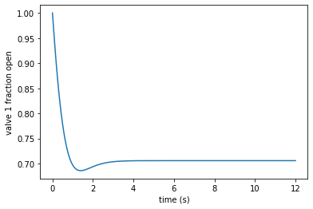

```python
a = plt.plot(tj.vecs["_time"], tj.vecs[str(m.fs.valve_1.valve_opening[12])])
a = plt.ylabel("valve 1 fraction open")
a = plt.xlabel("time (s)")
```

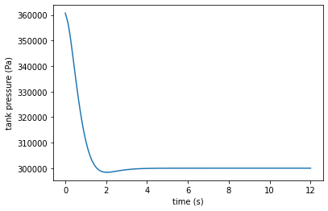

```python
a = plt.plot(tj.vecs["_time"], tj.vecs[str(m.fs.tank.control_volume.properties_out[12].pressure)])
a = plt.ylabel("tank pressure (Pa)")
a = plt.xlabel("time (s)")
```

## Model a ramp in inlet pressure

Next we show how to add an explicit time variable and ramp the inlet pressure from 500 kPa to 600 kPa between 10 and 12 seconds.

```python
# Create a new copy of the model that runs to 24 seconds, and add a constraint.

m = pid.create_model(
    time_set=[0, 24],
    nfe=1,
    calc_integ=True,
)
# time_var will be an explicit time variable we can use in constraints.
m.fs.time_var = pyo.Var(m.fs.time)

# We'll add a constraint to calculate the inlet pressure based on time,
# so we need to unfix pressure.
m.fs.valve_1.control_volume.properties_in[0].pressure.unfix()
m.fs.valve_1.control_volume.properties_in[24].pressure.unfix()

# The solver will directly set the time variable for the DAE solve, but
# solving the initial conditions is just a system of nonlinear equations,
# so we need to fix the initial time.
m.fs.time_var[0].fix(m.fs.time.first())

# We could break up the time domain and solve this in pieces, but creative use
# of min and max will let us create the ramping function we want.
# From 10s to 12s ramp inlet pressure from 500,000 Pa to 600,000 Pa
@m.fs.Constraint(m.fs.time)
def inlet_pressure_eqn(b, t):
    return b.valve_1.control_volume.properties_in[t].pressure == \
        smooth_min(600000, smooth_max(500000, 50000*(b.time_var[t] - 10) + 500000))
```

```
2022-03-08 01:23:06 [INFO] idaes.init.fs.valve_1: Initialization Complete: optimal - Optimal Solution Found
2022-03-08 01:23:06 [INFO] idaes.init.fs.tank.control_volume: Initialization Complete
2022-03-08 01:23:06 [INFO] idaes.init.fs.tank: Initialization Complete: optimal - Optimal Solution Found
2022-03-08 01:23:06 [INFO] idaes.init.fs.valve_2: Initialization Complete: optimal - Optimal Solution Found
```

```python
# Solve the new problem.  Notice the new argument specifying the explicit time variable.
res = petsc.petsc_dae_by_time_element(
    m,
    time=m.fs.time,
    timevar=m.fs.time_var,
    ts_options={
        "--ts_type":"beuler",
        "--ts_dt":0.1,
        "--ts_monitor":"", # set initial step to 0.1
        "--ts_save_trajectory":1,
        "--ts_trajectory_type":"visualization",
    },
    vars_stub="pid_tj2",
    trajectory_save_prefix="pid_tj2",
)
```

[output not shown]

[output cut: 162 more lines]

```
2022-03-08 01:23:11 [INFO] idaes.solve.petsc-dae: 152 TS dt 0.122168 time 13.3593
2022-03-08 01:23:11 [INFO] idaes.solve.petsc-dae: 153 TS dt 0.143966 time 13.4815
2022-03-08 01:23:11 [INFO] idaes.solve.petsc-dae: 154 TS dt 0.171146 time 13.6255
2022-03-08 01:23:11 [INFO] idaes.solve.petsc-dae: 155 TS dt 0.20087 time 13.7966
2022-03-08 01:23:11 [INFO] idaes.solve.petsc-dae: 156 TS dt 0.231498 time 13.9975
2022-03-08 01:23:11 [INFO] idaes.solve.petsc-dae: 157 TS dt 0.268692 time 14.229
2022-03-08 01:23:11 [INFO] idaes.solve.petsc-dae: 158 TS dt 0.323398 time 14.4977
2022-03-08 01:23:11 [INFO] idaes.solve.petsc-dae: 159 TS dt 0.415639 time 14.8211
2022-03-08 01:23:11 [INFO] idaes.solve.petsc-dae: 160 TS dt 0.591875 time 15.2367
2022-03-08 01:23:11 [INFO] idaes.solve.petsc-dae: 161 TS dt 0.991269 time 15.8286
2022-03-08 01:23:11 [INFO] idaes.solve.petsc-dae: 162 TS dt 2.16148 time 16.8198
2022-03-08 01:23:11 [INFO] idaes.solve.petsc-dae: 163 TS dt 5.01868 time 18.9813
2022-03-08 01:23:11 [INFO] idaes.solve.petsc-dae: 164 TS dt 21.6031 time 24.
2022-03-08 01:23:11 [INFO] idaes.solve.petsc-dae: TSConvergedReason = TS_CONVERGED_TIME
2022-03-08 01:23:11 [INFO] idaes.solve.petsc-dae: TS_CONVERGED_TIME
```

```python
tj = petsc.PetscTrajectory(json="pid_tj2_1.json.gz")
```

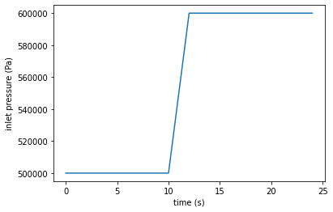

```python
a = plt.plot(tj.vecs["_time"], tj.vecs[str(m.fs.valve_1.control_volume.properties_in[24].pressure)])
a = plt.ylabel("inlet pressure (Pa)")
a = plt.xlabel("time (s)")
```

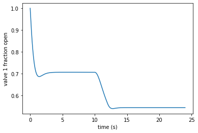

```python
a = plt.plot(tj.vecs["_time"], tj.vecs[str(m.fs.valve_1.valve_opening[24])])
a = plt.ylabel("valve 1 fraction open")
a = plt.xlabel("time (s)")
```

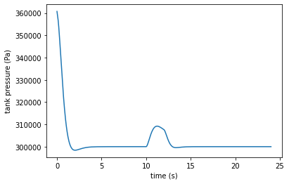

```python
a = plt.plot(tj.vecs["_time"], tj.vecs[str(m.fs.tank.control_volume.properties_out[24].pressure)])
a = plt.ylabel("tank pressure (Pa)")
a = plt.xlabel("time (s)")
```

The IDAES team:

- National Energy Technology Laboratory (Lead)
- Sandia National Laboratory
- Lawrence Berkeley National Laboratory
- Carnegie-Mellon University (subcontract to LBNL)
- West Virginia University (subcontract to LBNL)

General, background and overview information  
is available at the IDAES main website